# Relation between station usage and total amount of visitors at the exhibition

Rafal‚ Meysztowicz, Kamil Koziej, Mateusz Macias

May 10th 2016

Work division

- Mateusz Macias - R code, clustering and analysis
- Kamil Koziej - analisys, preparing data, presentation suppport
- Rafał Mejsztowicz - analisys, presentation

## Introduction

In our research we have concentrated on answering two questions:

1. How does amount of people visiting station depend on amount of all people visiting the exhibition?
2. How does mean visiting time on a station depend on amount of people visiting it?

Answering this two questions might lead to some interesting conclusions. For example if there is an amount of people in the exhibition over which amount of people visiting certain station does not grow anymore or even decrease. If so we could determine group of station for futher and deeper analysis. Maybe there is a need to put more than one copy of some stationsmaybe to fulfill the needs of visitors.

## Our problem

Let the set of indexes $I$ be a set of dates with time so that each element of $i$ would relate to one time interval of one day during which museum was open. In our case we used 15 minutes intervals.

As $S$ we will denote a set of stations. Let $X_i$ be the observation describing amount of people who visited the exhibition in $i$ from $I$ and $Y_{i,s}$ be the observations describing amount of people who visited station $s$ during time period $i$. We assume that $X_i$ and $Y_{i,s}$ are drawn from distribution denoted by random variables $(X,Y)$. We want to describe mutual correlation between X and Y. The problem might be stated as describing the function:
$$f_{s}(x) := E(Y_{s} | X)$$

We also want to see if increase of visitors logging into stations is always cousing the decrease of mean time that they spend on that station.

## Analysis

### Correlation between visits on stations and total amount of visitors on the exhibition

First of all we wanted to discover correlation between $X$ and $Y$. To do it we counted pearson correlation of $(X_i,Y_{i,s})_{i \in I}$ for every station from S.

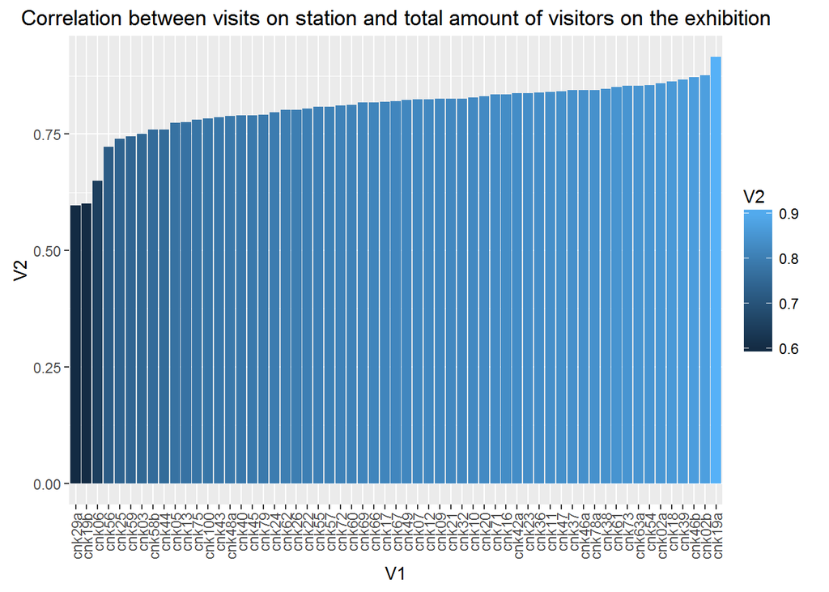

For most of stations this correlation is over 0.75 wih few exceptions around 0.6 which is most likely due to wrong usage of theese stations. Good exaple is station 19b, it seems that people do not realise that station 19 has 2 parts and ignore it even more when there are more visitors. The difference between stations 19 a and b behavior can be easly seen below:

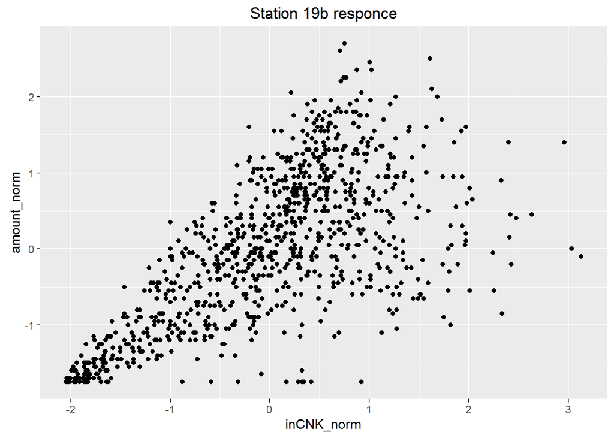

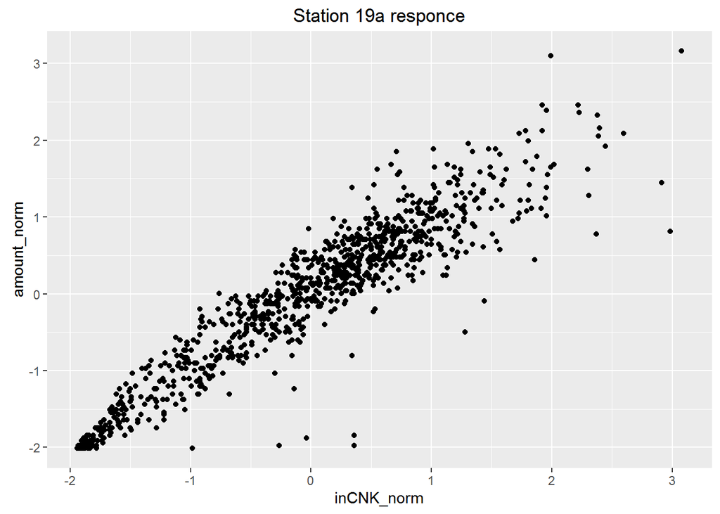

What we can notice is that interest in station 19a is growing linearly with total visitors increase and interest in station 19b is not growing that fast and maybe even decreasing at some point. Empirical analysis of such graths may not be very accurate, as some like in case of 19b may be scattered and harder to interpret. It should be much easier after we determine functions $f_{s}(x)$ .

Existence of such strong correlation between total and station visitors is not suprising, but the question to be answered is if each station respond for changes in total visitor amount in the same way.

To check if there are some “groups” of similar responces we decided to perform clustering.

### Determining the $f_{s}(x)$ funtions

Correlation is only one variable description of mutual behavior of X and Y. We wanted to check if different stations have different patterns of relation betwean X and Y. Easily stated we wanted to check how much $f_{s}(x)$ differs for different stations. To be able to compare shapes of $f_s(x)$ we decided to normalize X and Y. To do it we counted
$$(X_i,Y_{i,s})_{i in I} := \frac{(X_i,Y_{i,s})_{i in I} - mean((X_i,Y_{i,s})_{i in I})}{stdev((X_i,Y_{i,s})_{i \in I})}$$
.

To perform clustering we had to choose the distance measure. In order to do so we’ve decided to determine functions that could descibe the behavior of the stations:
$$f_{s}(x) := E(Y_{s} | X)$$

and then measure the distaces.

We estimated the functions using SVM algorithm.

SVM is an algorithm that - given a set of points S from some space $R^{n+1}$, gives us a function from L2 $f:R^n -> R$ that minimizes an error function. An error function is defined as mean square error between set S and values of f in coresponding points, increased by a bias which depends on f only (and not S). The greatest problem with SVM algorithm is that it very easily overfits. In our case this didn’t appear to be a problem because our space is low dimensional, and set of points is pretty dense. After very little adjustment of parameters curve given by SVM seems to generalise data very well.

### Clustering

Having “comparable” datapoints and f_{s}(x) functions assigned to them we could start clustering.

First of all we had to decide what norm do we want to use. We decided to try some classic norms for functions. We tried out L2([-2,3]) and sup([-2,3]) where [-2,3] was a notion of normalised variable $X$.

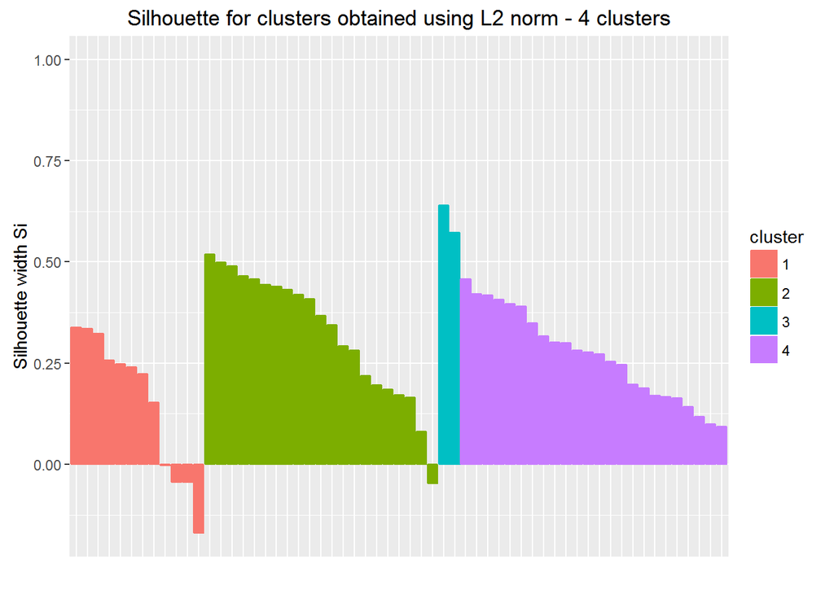

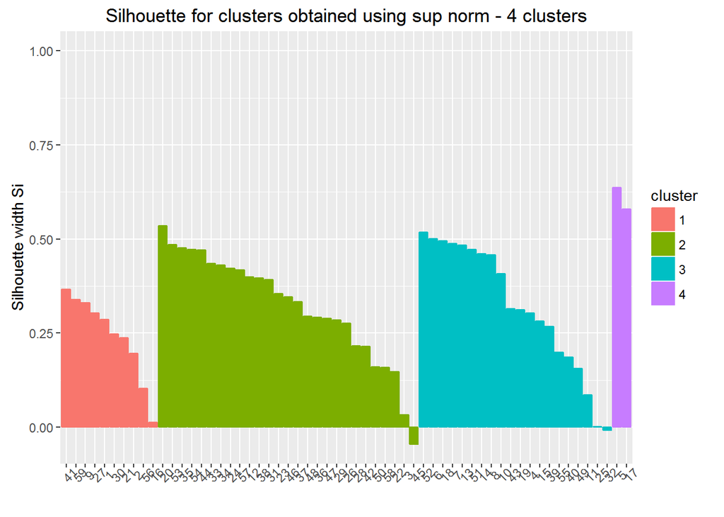

In both cases clusters appeared to be very similar, although we can see that supremum norm gives us better results. Silhoutte shows us that L2 norm is giving less accurate cluster assignment. For both norms 4 clusters appeared to be an optimal amount. For the comparison we can see below how silhoutte looks for 3 clusters.

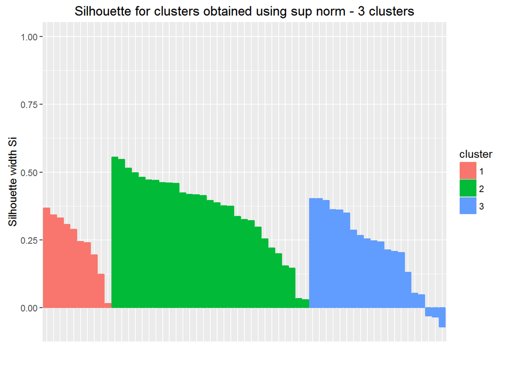

Obtained clusters:

1: cnk02a cnk02b cnk100 cnk19a cnk23 cnk36 cnk39 cnk54 cnk73 cnk79

2: cnk03 cnk13 cnk22 cnk24 cnk25 cnk26 cnk32 cnk37 cnk38 cnk40 cnk43 cnk44 cnk45 cnk46a cnk46b cnk47 cnk55 cnk57 cnk58b cnk59 cnk60 cnk61 cnk63a cnk69 cnk71 cnk75 cnk78a

3: cnk05 cnk07 cnk09 cnk10 cnk11 cnk12 cnk16 cnk17 cnk18 cnk20 cnk21 cnk29a cnk42a cnk48a cnk49 cnk56 cnk62 cnk66 cnk67 cnk72

4: cnk06 cnk19b

Therefore, we’ve obtained 4 patterns each showing slightly different responce.

Here we can see plots of medoids after clustering. Horizontal axis represents number of people at the exhibition and vertical axis shows amount of visitors on focused station. Graphs differ in various aspects, as we are about to discuss.

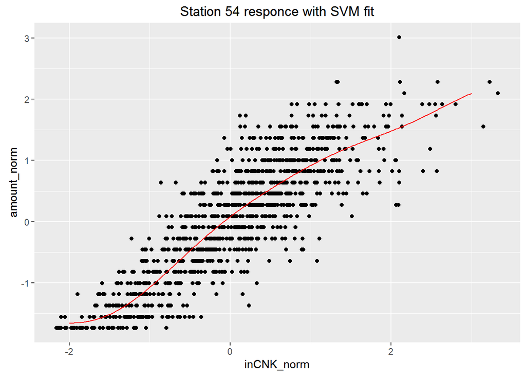

First cluster stands for stations that represents behaviour of visitors that we easly predicted - the amount of visitors on exhibits is proportional to number of people in CNK. Here we have simple linear dependency.

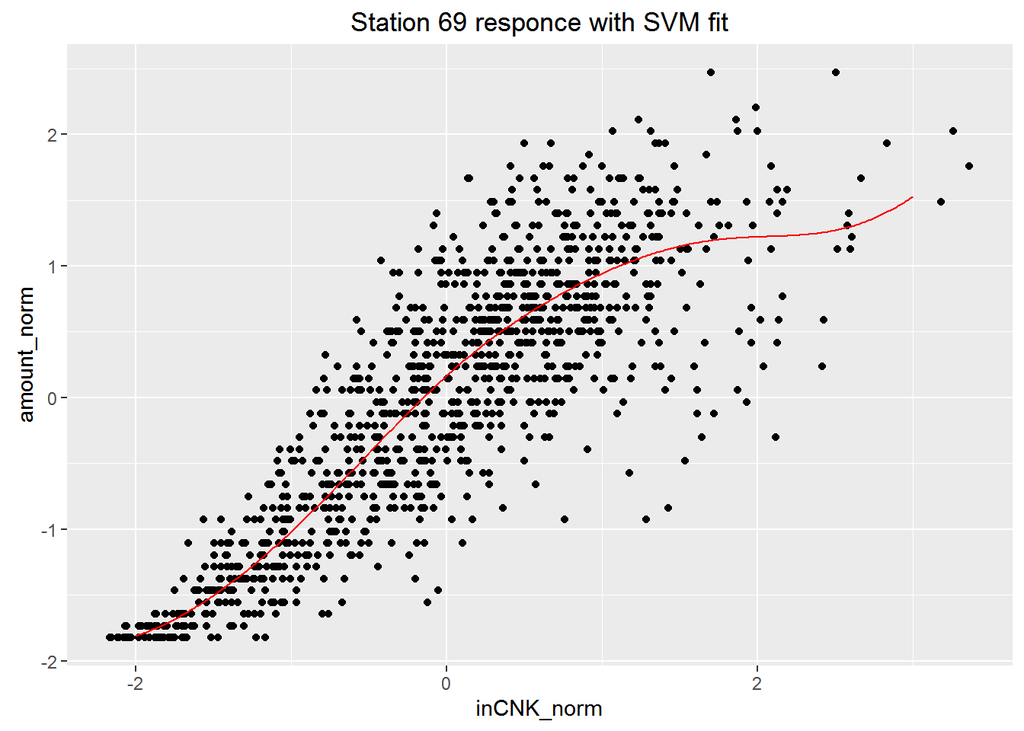

In the second group we occour anon trivial difference. At the point 1.5 our function slows down - propably due to mximum number of visitors it can handle.

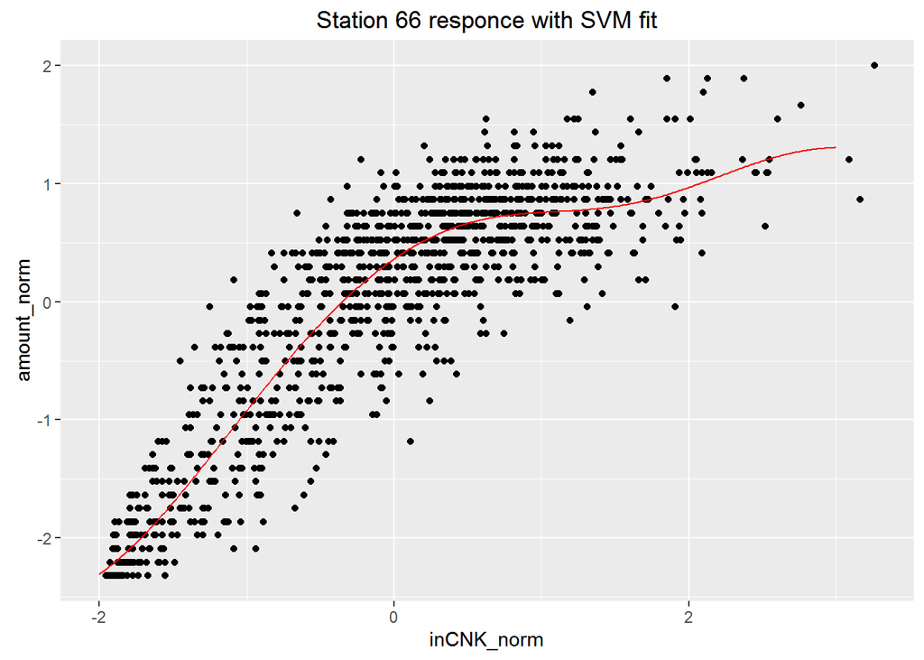

The only difference beetween this cluster and the previous one is the appearence of inflection point. Here we encounter it around point 0.5.

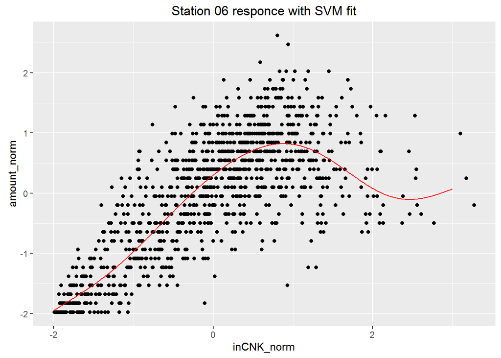

### Correlation between visits on stations and mean time spent on them by visitots

Correlation between visits on stations and mean time spend on them by visitots is less obvious. We would assume that strong dependence should appear. As more people are visiting each station, there should be significant decrease of mean time spent on the station.

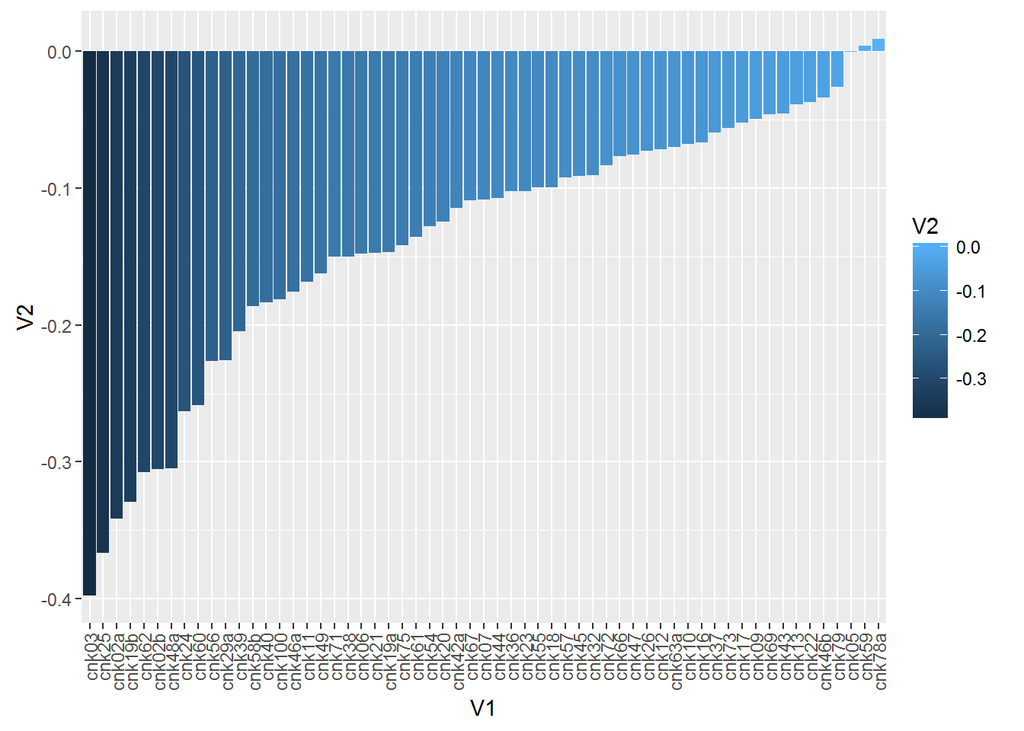

As predicted most of correlations are significant. Althought it’s important to note that correlations are much lower than between visits on stations and total amount of visitors on the exhibition, and also around 1/4 of the stations have mean usage times completely independent of amount of its visitors.

Conclusions:

- There seems to be 4 main patterns of reaction on stations for increased ammount of people in CNK
- Two stations are visited by less visitors if CNK is visited by more people
- There are two thresholds above which amount of people visiting specific stations stops to increase
- Most stations are visited more superficialy if too many people are trying to visit it. Some stations seem to be unafected by a fact.